# Session 6: Homework 3

# 5 Challenge 2: CDC COVID-19 Public Use Data

The [CDC Covid-19 Case Surveillance Data](https://data.cdc.gov/Case-Surveillance/COVID-19-Case-Surveillance-Public-Use-Data/vbim-akqf) is a case surveillance public use dataset with 12 elements for all COVID-19 cases shared with CDC and includes demographics, any exposure history, disease severity indicators and outcomes, presence of any underlying medical conditions and risk behaviors. You can see the variables from

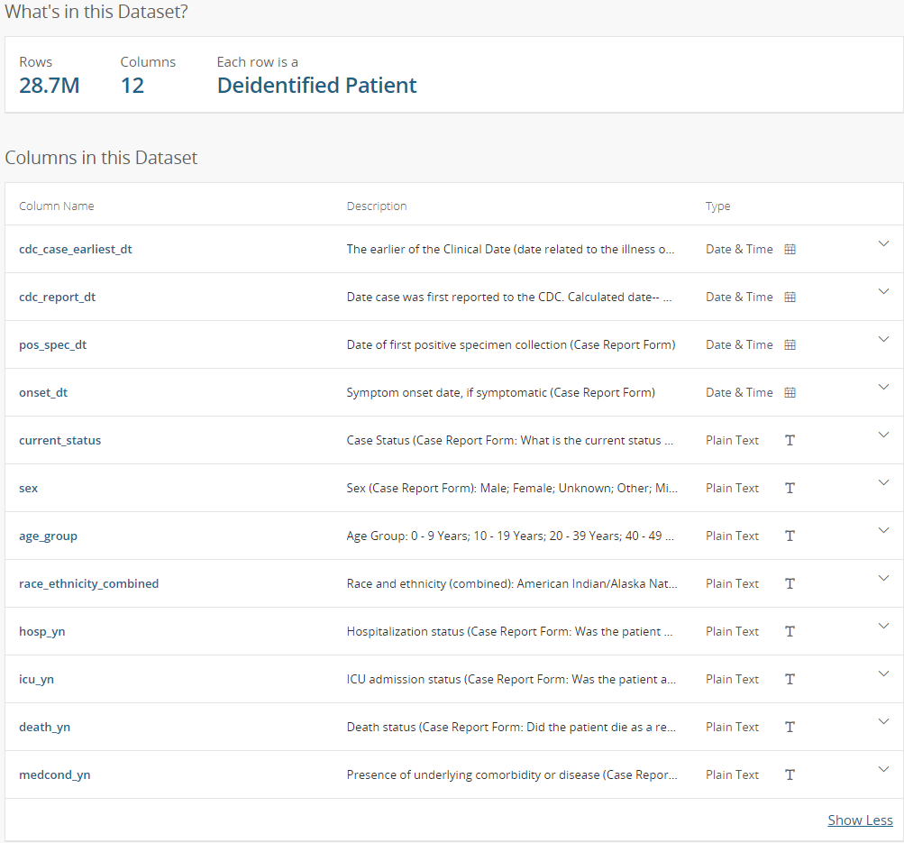

There are well over 28 million entries of individual, and we will work with SQLlite database, rather than a CSV file. I would like you to produce two graphs that show death % rate:

1. by age group, sex, and whether the patient had co-morbidities or not
2. by age group, sex, and whether the patient was admited to Intensive Care Unit (ICU) or not.

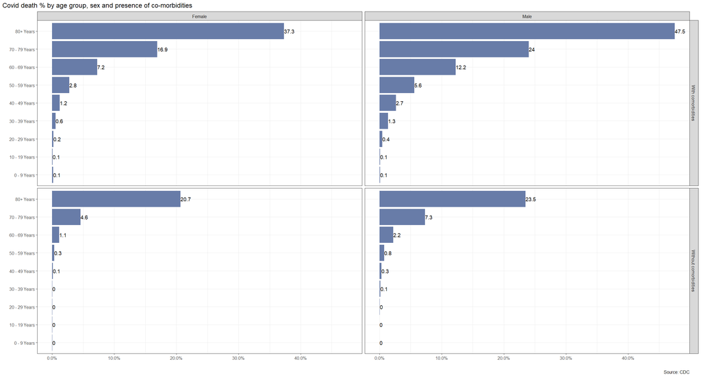

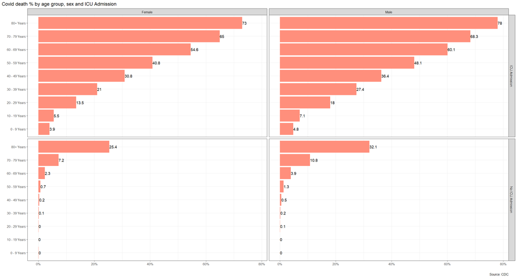

```r
# more details and examples on connecting to an SQL database can be found at
# https://mam2022.netlify.app/reference/reference_sql/

# set up a connection to sqlite database.
# make sure the database file is in your working directory--
# put it at the root of am01

my_path <- "/Users/gaoyuan/Downloads/cdc_data.db"

cdc_db <- DBI::dbConnect(
  drv = RSQLite::SQLite(),
  dbname = my_path
)

# browse the tables in the database using DBI::dbListTables()
DBI::dbListTables(cdc_db)
```

```
## [1] "cdc"
```

```r
# We can easily set these tables up as database objects using dplyr
cdc_data <- dplyr::tbl(cdc_db, "cdc")



# ************************
# You need to calculate Covid death % by age group, sex
# and presence of co-morbidities (query1) and Covid death %
# by age group, sex and ICU admission (query2)

# rather than loading the entire file in memory, you will use dplyr+SQL,
# to generate a smaller dataset that you will use for your calculations and
# thn visualisations

query1 <- cdc_data %>%
  filter(death_yn %in% c("Yes","No") &
           !age_group %in% c("Missing","NA") &
           sex %in% c("Male","Female") &
           medcond_yn %in% c("Yes","No")) %>%
  mutate(medcond_yn = case_when(
    medcond_yn == "Yes" ~ "With Comorbidities",
    medcond_yn == "No" ~ "Without Comorbidities"
  )) %>%
  group_by(age_group, sex, death_yn, medcond_yn) %>%
  summarise(count=n())


# query1 is a list of database connection, operations, sql
class(query1)
```

```
## [1] "tbl_SQLiteConnection" "tbl_dbi"              "tbl_sql"
## [4] "tbl_lazy"             "tbl"
```

```r
# Generate actual SQL commands: We can either use dbplyr::sql_render() or dplyr::show_query()
dbplyr::sql_render(query1)
```

```
## <SQL> SELECT `age_group`, `sex`, `death_yn`, `medcond_yn`, COUNT(*) AS `count`
## FROM (SELECT `cdc_case_earliest_dt`, `cdc_report_dt`, `pos_spec_dt`, `onset_dt`, `current_status`, `sex`, `age_group`, `race_ethnicity_combined`, `hosp_yn`, `icu_yn`, `death_yn`, CASE
## WHEN (`medcond_yn` = 'Yes') THEN ('With Comorbidities')
## WHEN (`medcond_yn` = 'No') THEN ('Without Comorbidities')
## END AS `medcond_yn`
## FROM `cdc`
## WHERE (`death_yn` IN ('Yes', 'No') AND NOT(`age_group` IN ('Missing', 'NA')) AND `sex` IN ('Male', 'Female') AND `medcond_yn` IN ('Yes', 'No')))
## GROUP BY `age_group`, `sex`, `death_yn`, `medcond_yn`
```

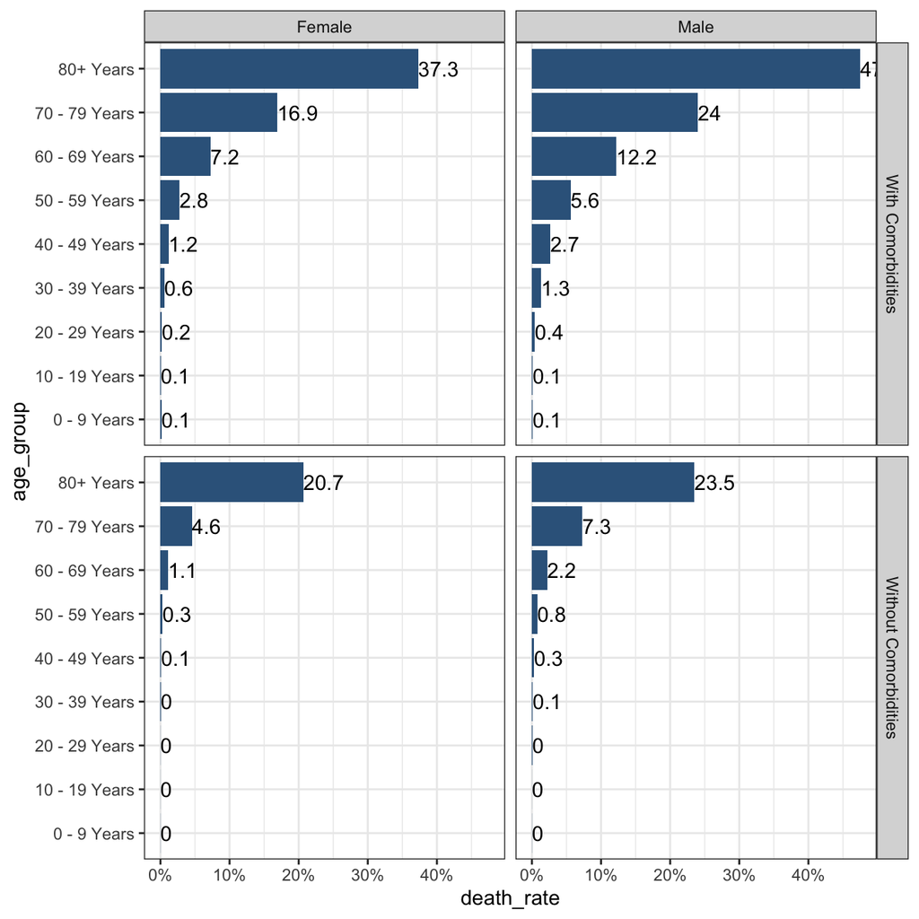

```r
# execute query and retrieve results in a tibble (dataframe).
query1_tibble <- query1 %>%
  collect() # collect runs the SQL query and returns the output of your dplyr pipe sequence

# calculate death rate
query1_tibble %>%
  pivot_wider(names_from = death_yn,values_from=count) %>%
  mutate(death_rate = Yes/(No+Yes)) %>%
  # bar plot
  ggplot(aes(x=death_rate,y=age_group))+
  geom_col(fill="steelblue4")+
  # data label
  geom_text(aes(label = round(death_rate*100,1),hjust=0))+
  # 2x2 grid faceting
  facet_grid(medcond_yn ~ sex) +
  # x axis in %
  scale_x_continuous(label=scales::percent_format(accuracy = 1))+
  theme_bw()+
  labs()+
  NULL
```

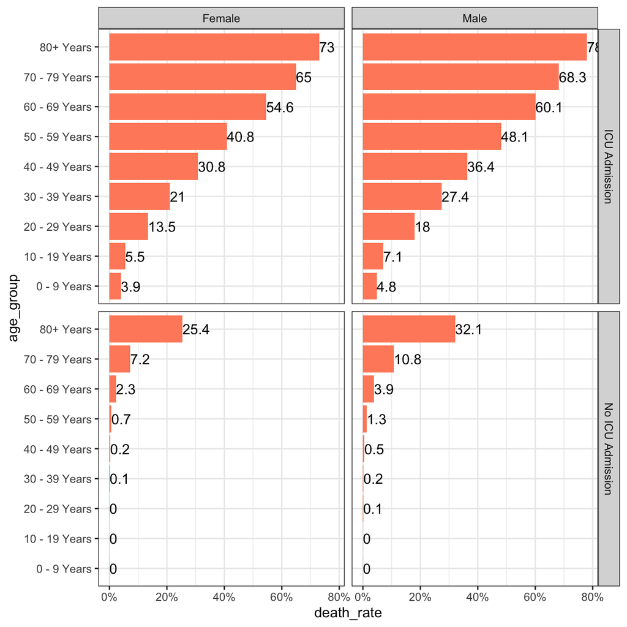

```r
query2 <- cdc_data %>%
  filter(icu_yn %in% c("Yes","No") &
           !age_group %in% c("Missing","NA") &
           sex %in% c("Male","Female") &
           death_yn %in% c("Yes","No")) %>%
  mutate(icu_yn = case_when(
    icu_yn == "Yes" ~ "ICU Admission",
    icu_yn == "No" ~ "No ICU Admission"
  )) %>%
  group_by(age_group, sex, icu_yn, death_yn) %>%
  summarise(count=n())

query2_tibble <- query2 %>%
  collect()

# calculate icu rate
query2_tibble %>%
  pivot_wider(names_from = death_yn, values_from=count) %>%
  mutate(death_rate = Yes/(No+Yes))%>%
  # bar plot
  ggplot(aes(x=death_rate,y=age_group))+
  geom_col(fill="salmon1")+
  # data label
  geom_text(aes(label = round(death_rate*100,1),hjust=0))+
  # 2x2 grid faceting
  facet_grid(icu_yn ~ sex) +
  # x axis in %
  scale_x_continuous(label=scales::percent_format(accuracy = 1))+
  theme_bw()+
  labs()+
  NULL
```

# 6 Challenge 3:GDP components over time and among countries

At the risk of oversimplifying things, the main components of gross domestic product, GDP are personal consumption (C), business investment (I), government spending (G) and net exports (exports - imports). You can read more about GDP and the different approaches in calculating at the [Wikipedia GDP page](https://en.wikipedia.org/wiki/Gross_domestic_product).

The GDP data we will look at is from the [United Nations’ National Accounts Main Aggregates Database](https://unstats.un.org/unsd/snaama/Downloads), which contains estimates of total GDP and its components for all countries from 1970 to today. We will look at how GDP and its components have changed over time, and compare different countries and how much each component contributes to that country’s GDP. The file we will work with is [GDP and its breakdown at constant 2010 prices in US Dollars](http://unstats.un.org/unsd/amaapi/api/file/6) and it has already been saved in the Data directory. Have a look at the Excel file to see how it is structured and organised

```r
UN_GDP_data  <-  read_excel(here::here("data", "Download-GDPconstant-USD-countries.xls"), # Excel filename
                sheet="Download-GDPconstant-USD-countr", # Sheet name
                skip=2) # Number of rows to skip
```

The first thing you need to do is to tidy the data, as it is in wide format and you must make it into long, tidy format. Please express all figures in billions (divide values by `1e9`, or $10^9$), and you want to rename the indicators into something shorter.

```r
# check unique values of IndicatorName
unique(UN_GDP_data$IndicatorName)
```

```
##  [1] "Final consumption expenditure"
##  [2] "Household consumption expenditure (including Non-profit institutions serving households)"
##  [3] "General government final consumption expenditure"
##  [4] "Gross capital formation"
##  [5] "Gross fixed capital formation (including Acquisitions less disposals of valuables)"
##  [6] "Exports of goods and services"
##  [7] "Imports of goods and services"
##  [8] "Gross Domestic Product (GDP)"
##  [9] "Agriculture, hunting, forestry, fishing (ISIC A-B)"
## [10] "Mining, Manufacturing, Utilities (ISIC C-E)"
## [11] "Manufacturing (ISIC D)"
## [12] "Construction (ISIC F)"
## [13] "Wholesale, retail trade, restaurants and hotels (ISIC G-H)"
## [14] "Transport, storage and communication (ISIC I)"
## [15] "Other Activities (ISIC J-P)"
## [16] "Total Value Added"
## [17] "Changes in inventories"
```

```r
tidy_GDP_data  <- UN_GDP_data %>%
  pivot_longer(cols = 4:51, names_to = "year", values_to = "volume") %>%
  mutate(volume_bn = volume / 10^9, IndicatorName = case_when (
    IndicatorName == "Household consumption expenditure (including Non-profit institutions serving households)" ~ "Household expenditure",
    IndicatorName == "Exports of goods and services" ~ "Exports",
    IndicatorName == "Imports of goods and services" ~ "Imports",
    IndicatorName == "General government final consumption expenditure" ~ "Government expenditure",
    IndicatorName == "Gross capital formation" ~ "Gross capital formation",
    IndicatorName == "Gross Domestic Product (GDP)" ~ "Gross Domestic Product",
    T~"Others")) %>%
  filter(IndicatorName!="Others")

glimpse(tidy_GDP_data)
```

```
## Rows: 63,072
## Columns: 6
## $ CountryID     <dbl> 4, 4, 4, 4, 4, 4, 4, 4, 4, 4, 4, 4, 4, 4, 4, 4, 4, 4, 4,…
## $ Country       <chr> "Afghanistan", "Afghanistan", "Afghanistan", "Afghanista…
## $ IndicatorName <chr> "Household expenditure", "Household expenditure", "House…
## $ year          <chr> "1970", "1971", "1972", "1973", "1974", "1975", "1976", …
## $ volume        <dbl> 5.07e+09, 4.84e+09, 4.70e+09, 5.21e+09, 5.59e+09, 5.65e+…
## $ volume_bn     <dbl> 5.07, 4.84, 4.70, 5.21, 5.59, 5.65, 5.68, 6.15, 6.30, 6.…
```

```r
# Let us compare GDP components for these 3 countries
country_list <- c("United States","India", "Germany")
tidy_GDP_country <- tidy_GDP_data %>%
  filter (Country %in% country_list)

head(tidy_GDP_country)
```

```
## # A tibble: 6 × 6
##   CountryID Country IndicatorName         year   volume volume_bn
##       <dbl> <chr>   <chr>                 <chr>   <dbl>     <dbl>
## 1       276 Germany Household expenditure 1970  8.72e11      872.
## 2       276 Germany Household expenditure 1971  9.19e11      919.
## 3       276 Germany Household expenditure 1972  9.69e11      969.
## 4       276 Germany Household expenditure 1973  9.97e11      997.
## 5       276 Germany Household expenditure 1974  9.95e11      995.
## 6       276 Germany Household expenditure 1975  1.03e12     1032.
```

First, can you produce this plot?


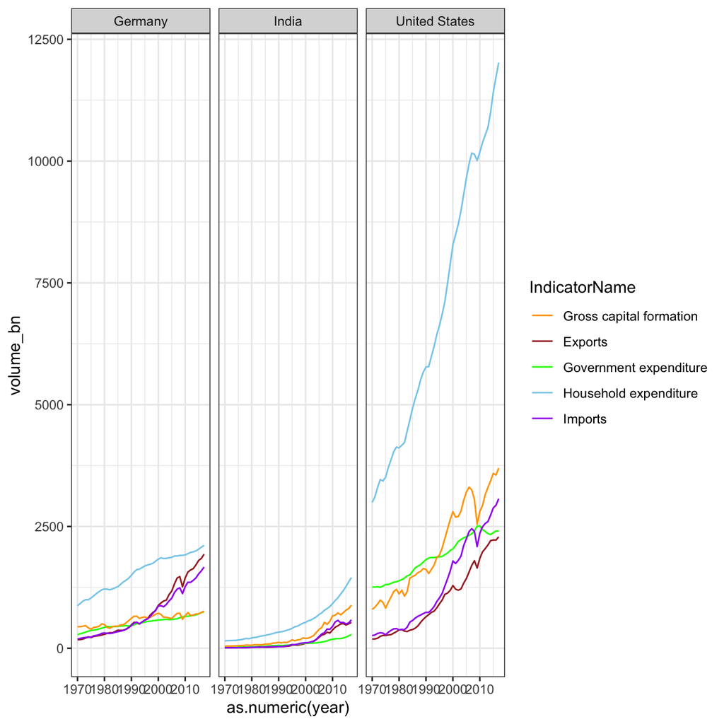

```r
tidy_GDP_country %>%
  filter(IndicatorName!="Gross Domestic Product") %>%
  ggplot(aes(x=as.numeric(year),y=volume_bn,
             color = IndicatorName)) +
  geom_line() +
  facet_wrap(~Country) +
  theme_bw() +
  scale_colour_manual(breaks = c("Gross capital formation", "Exports", "Government expenditure", "Household expenditure", "Imports"),
                      values = c("orange","brown","green","sky blue","purple")) +
  labs()+
  NULL
```

Secondly, recall that GDP is the sum of Household Expenditure (Consumption *C*), Gross Capital Formation (business investment *I*), Government Expenditure (G) and Net Exports (exports - imports). Even though there is an indicator `Gross Domestic Product (GDP)` in your dataframe, I would like you to calculate it given its components discussed above.

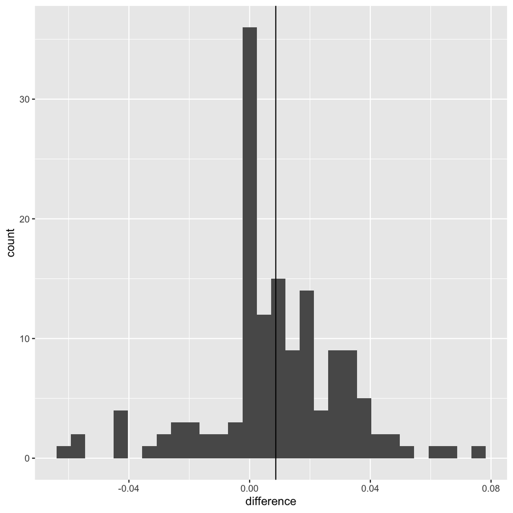

```r
GDP_components <- tidy_GDP_country %>%
  select(-volume) %>%
  pivot_wider(names_from = IndicatorName,
              values_from = volume_bn)

# modify column names
colnames(GDP_components) <- gsub(" ","_", colnames(GDP_components) )

# calculate GDP
GDP_components <- GDP_components %>%
  mutate(GDP = Household_expenditure +
           Government_expenditure +
           Gross_capital_formation +
           Exports - Imports)

GDP_components %>%
  mutate(difference = (GDP-Gross_Domestic_Product)/Gross_Domestic_Product) %>%
  ggplot(aes(x=difference))+
  geom_histogram(bins=30) +
  geom_vline(aes(xintercept=mean(difference)))+
  labs()+
  NULL
```

> What is the % difference between what you calculated as GDP and the GDP figure included in the dataframe?


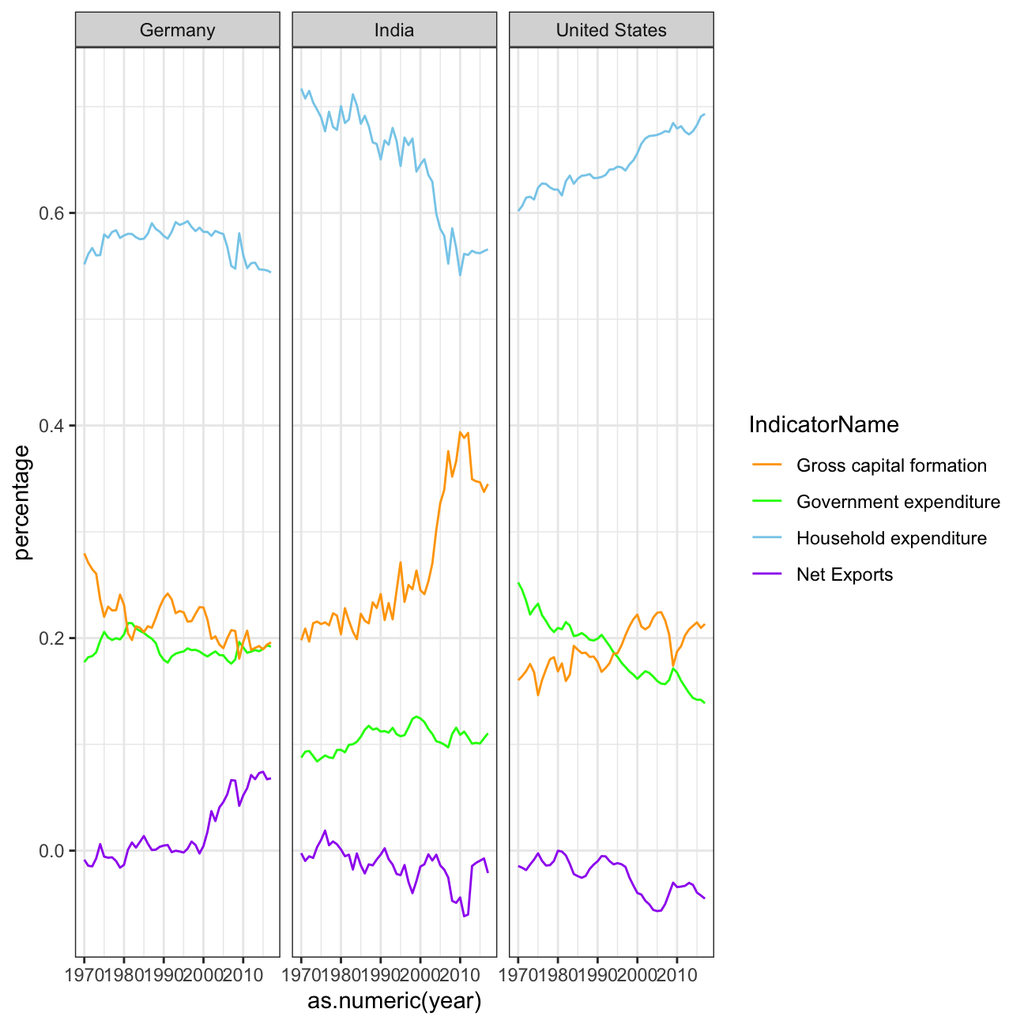

```r
GDP_components %>%
  mutate(Household_expenditure = Household_expenditure/GDP,
         Government_expenditure  =  Government_expenditure/GDP,
         Gross_capital_formation = Gross_capital_formation/GDP,
         Net_Exports = (Exports - Imports)/GDP) %>%
  select(c("CountryID","Country","year",
           "Household_expenditure","Government_expenditure","Gross_capital_formation","Net_Exports")) %>%
  pivot_longer(4:7,
               names_to = "IndicatorName",
               values_to = "percentage") %>%
  mutate(IndicatorName = gsub("_"," ",IndicatorName)) %>%
  ggplot(aes(x=as.numeric(year),y=percentage,
             color = IndicatorName)) +
  geom_line() +
  facet_wrap(~Country) +
  theme_bw() +
  scale_colour_manual(breaks = c("Gross capital formation", "Government expenditure", "Household expenditure", "Net Exports"),
                      values = c("orange","green","sky blue","purple")) +
  labs()+
  NULL
```

> What is this last chart telling you? Can you explain in a couple of paragraphs the different dynamic among these three countries?

> If you want to, please change `country_list <- c("United States","India", "Germany")` to include your own country and compare it with any two other countries you like

# 7 Deliverables

There is a lot of explanatory text, comments, etc. You do not need these, so delete them and produce a stand-alone document that you could share with someone. Knit the edited and completed R Markdown file as an HTML document (use the “Knit” button at the top of the script editor window) and upload it to Canvas.

# 8 Details

Team Members: Alex Kubbinga, Clara Moreno Sanchezu, Jean Huang, Raghav Mehta, Raina Doshi, Yuan Gao

**Please seek out help when you need it,** and remember the [15-minute rule](https://mam2022.netlify.app/syllabus/#the-15-minute-rule). You know enough R (and have enough examples of code from class and your readings) to be able to do this. If you get stuck, ask for help from others, post a question on Slack– and remember that I am here to help too!

> As a true test to yourself, do you understand the code you submitted and are you able to explain it to someone else?

# 9 Rubric

Check minus (1/5): Displays minimal effort. Doesn’t complete all components. Code is poorly written and not documented. Uses the same type of plot for each graph, or doesn’t use plots appropriate for the variables being analyzed.

Check (3/5): Solid effort. Hits all the elements. No clear mistakes. Easy to follow (both the code and the output).

Check plus (5/5): Finished all components of the assignment correctly and addressed both challenges. Code is well-documented (both self-documented and with additional comments as necessary). Used tidyverse, instead of base R. Graphs and tables are properly labelled. Analysis is clear and easy to follow, either because graphs are labeled clearly or you’ve written additional text to describe how you interpret the output.